# Model 1

- Package Installation

```r
library("rethinking")
library(dplyr)
library(dagitty)
par(mfrow = c(2, 2))
```

## Causal effects of the DAG

```r
kdag<-dagitty("dag {
  S-> K <- T
  T -> S
  T -> SL -> K
}")
adjustmentSets(kdag, exposure="SL", outcome = "K")# This shows the backdoor path and how to stratify
```

```
## { T }
```

## Synthetic Data

- create a synthetic data with assumptions. See overview.pdf to check the data relationship.

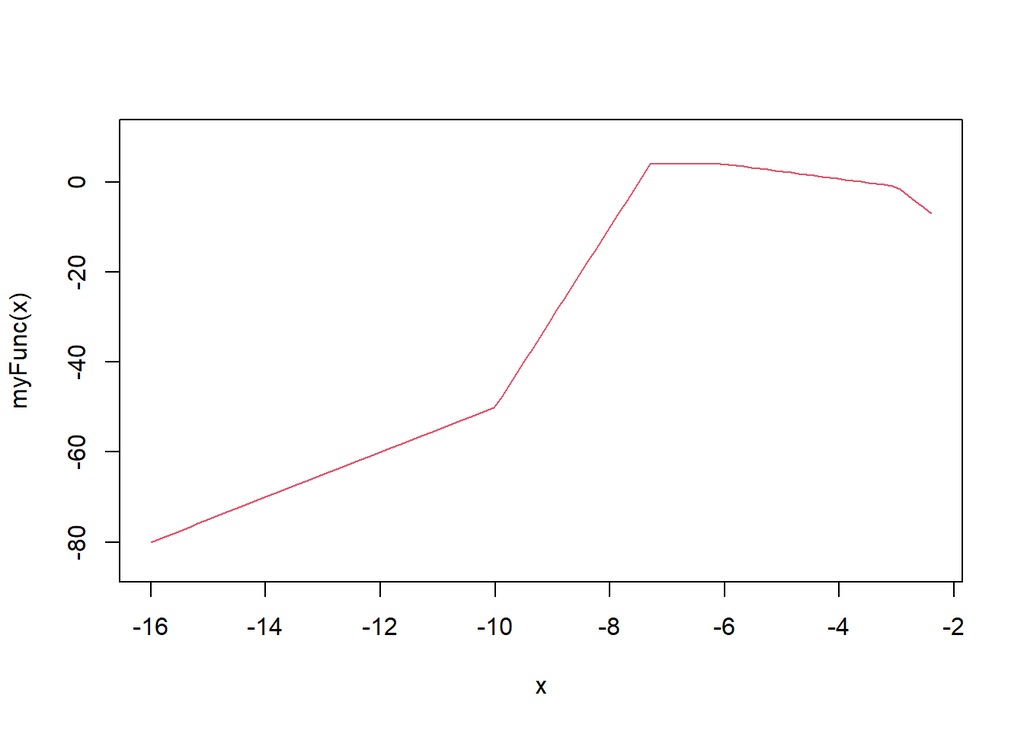

```r
# Function of SL by Y
myFunc <- function(x) {
case_when(
    -16.000 <= x & x <= -10   ~ (x + 16) * 30 / 6 - 80,
    -10.000 < x  & x <= -7.300 ~ (x + 10) * 60 / 3 - 50,
    -7.300 < x   & x <= -6    ~ 4,
    -6.000 < x   & x <= -3.000 ~ (x + 6) * (-5) / 3 + 4,
    -3.000 < x   & x <= -2.400 ~ (x + 3) * (-5) / 0.5 - 1,
    TRUE                      ~ 1
  )
}
curve(myFunc(x), col = 2, xlim=c(-16.000, -2.400), ylim=c(-85, 10))
```

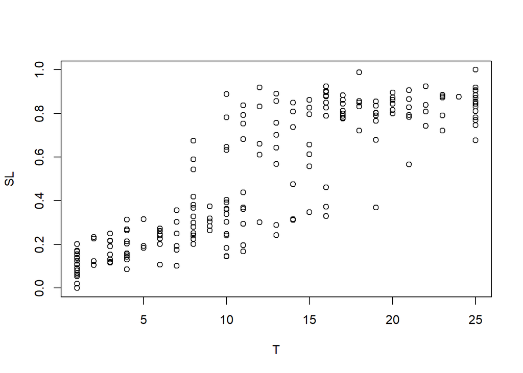

```r
# Initialize Y
Y<- runif(200, -16, -2.4)

# T and SL caused by Y
T<- NULL
SL<-NULL
for (i in 1:length(Y)) {
    T[i]<-rpois(1,  (Y[i]+16)/13.6 * 25)
    if(T[i] < 1) {T[i]<- 1}
    else if(T[i] > 25) {T[i]<- 25} # Make sure T is between 1 and 25
    SL[i]<- rnorm(1, myFunc(Y[i]), 5)
}

SL <- (SL - min(SL)) / (max(SL) - min(SL)) # to estimate easily, make it between 0 and 1

# Check the data
plot(T, SL)
```

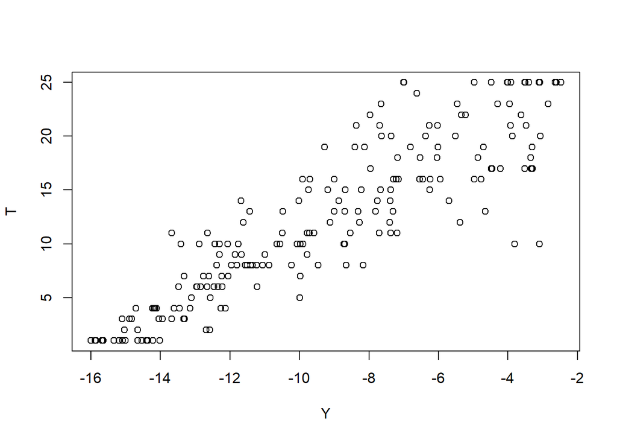

```r
plot(Y, T)
```

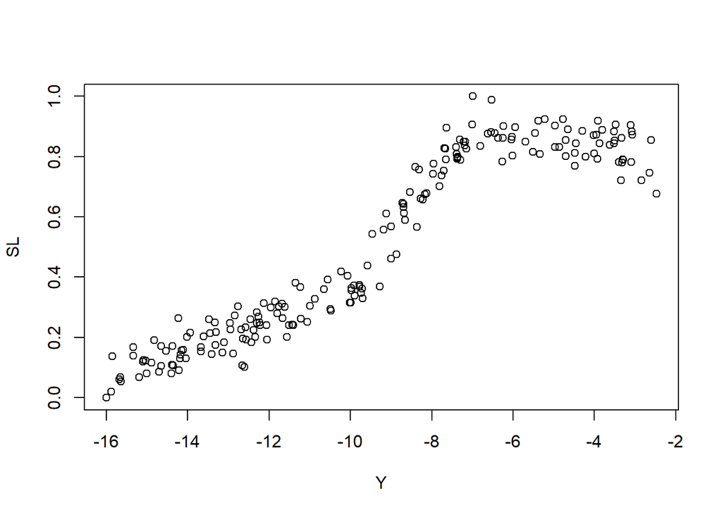

```r
plot(Y, SL)
```

```r
# initialize dS with random numbers
dS<-rbeta(length(T), 1.2,1) * 200
# S is affected by Y and dS (omit T as T and S are correlated by Y)
S<-NULL
for(i in 1:length(T))S[i] <- rnorm(1, 0.3*Y[i] -dS[i]/50, 0.1)/25 + 0.4

# Check the data
range(S) # try to make less than 0.5
```

```
## [1] 0.06526578 0.33710071
```

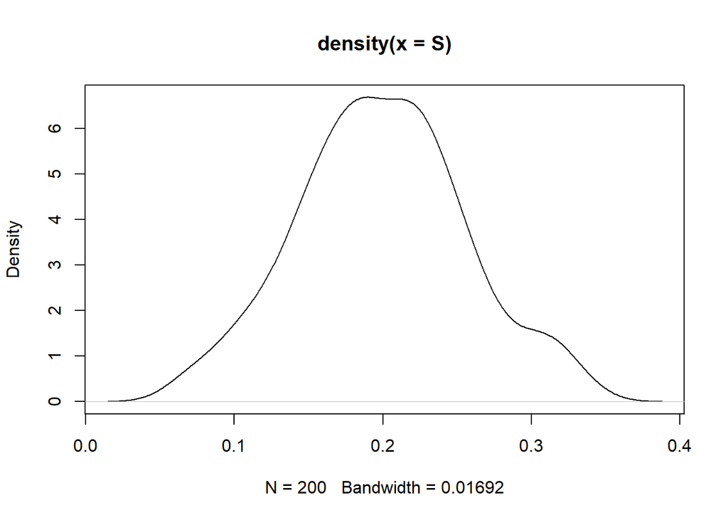

```r
plot(density(S))
```

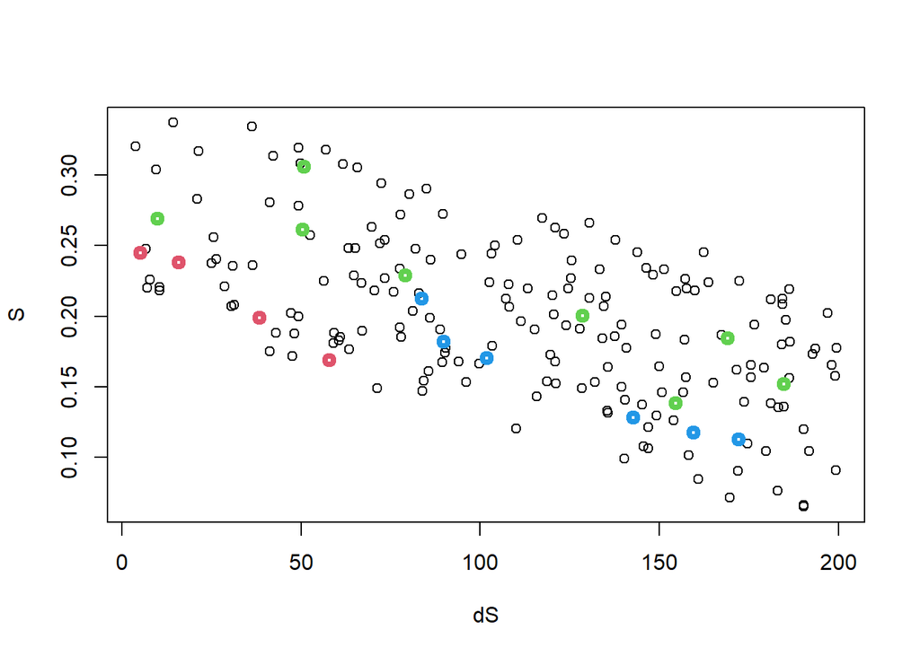

```r
plot(dS, S)
points(dS[T==2], S[T==2], col = 2, lwd =4)
points(dS[T==13], S[T==13], col = 3, lwd =4)
points(dS[T==7], S[T==7], col = 4, lwd =4)
```

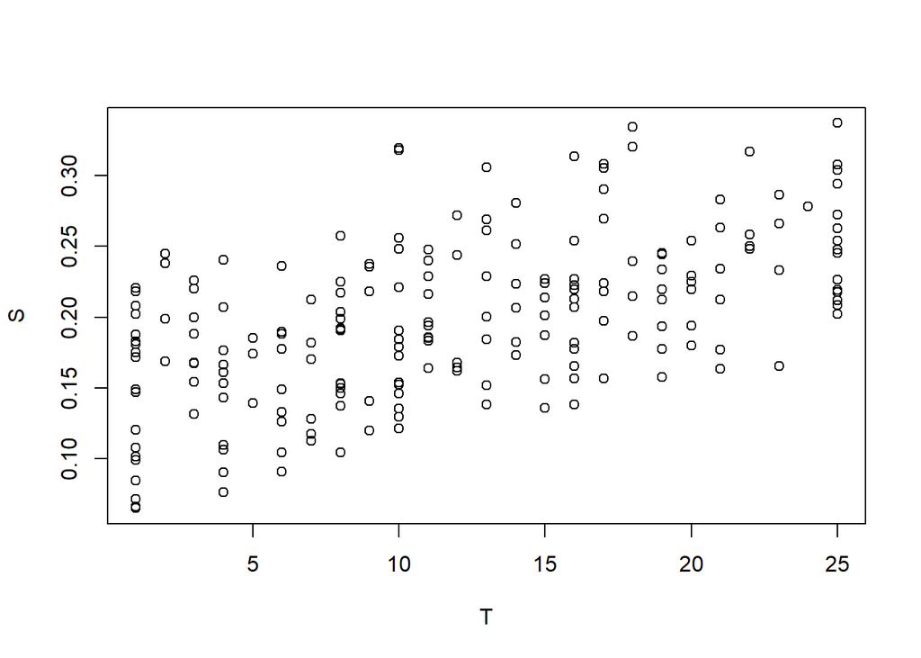

```r
plot(T, S)
```

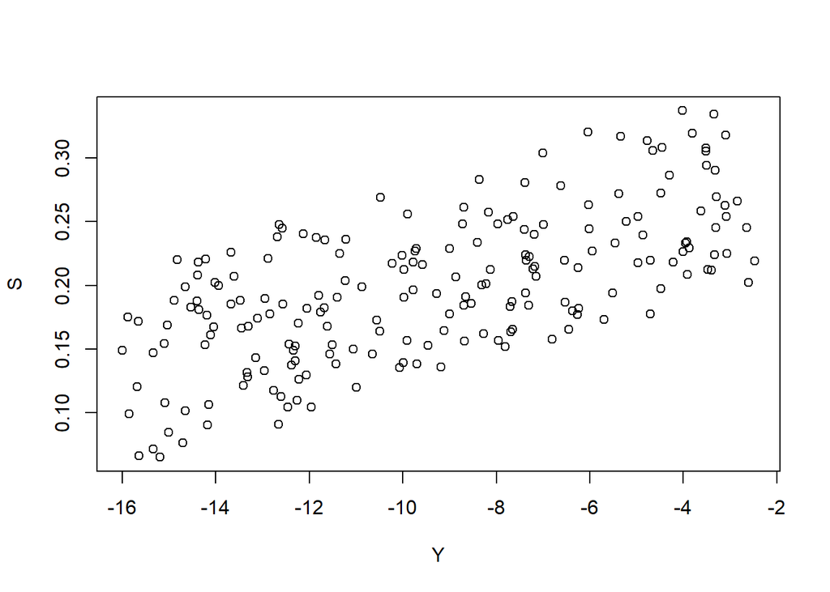

```r
plot(Y, S)
```

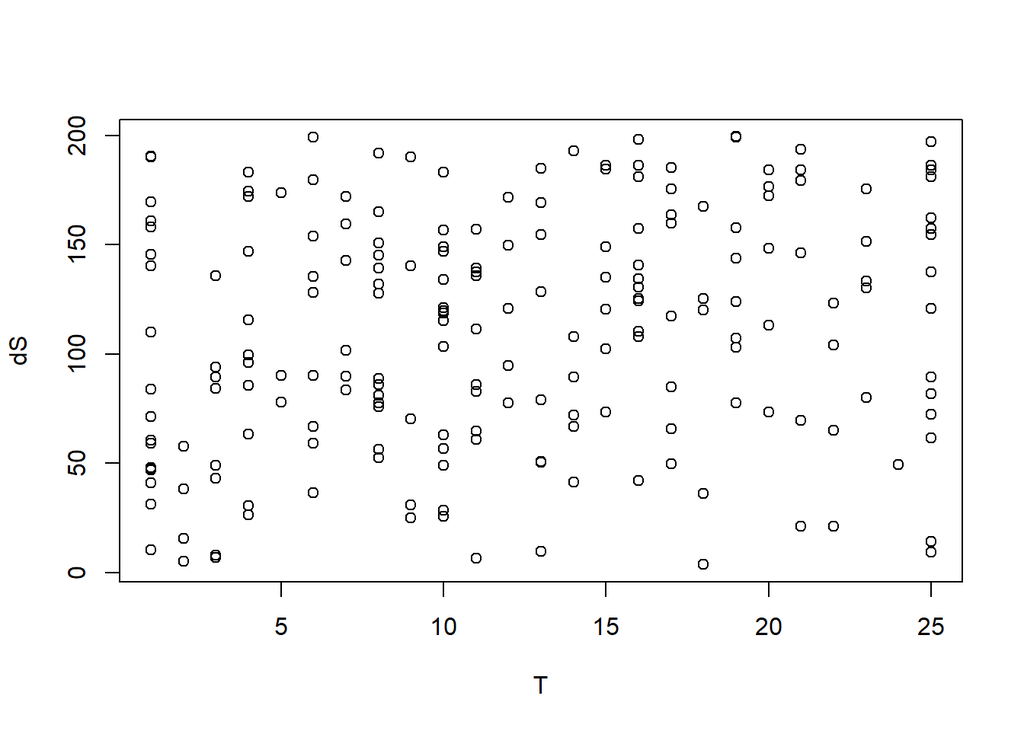

```r
plot(T, dS) # no correlation
```

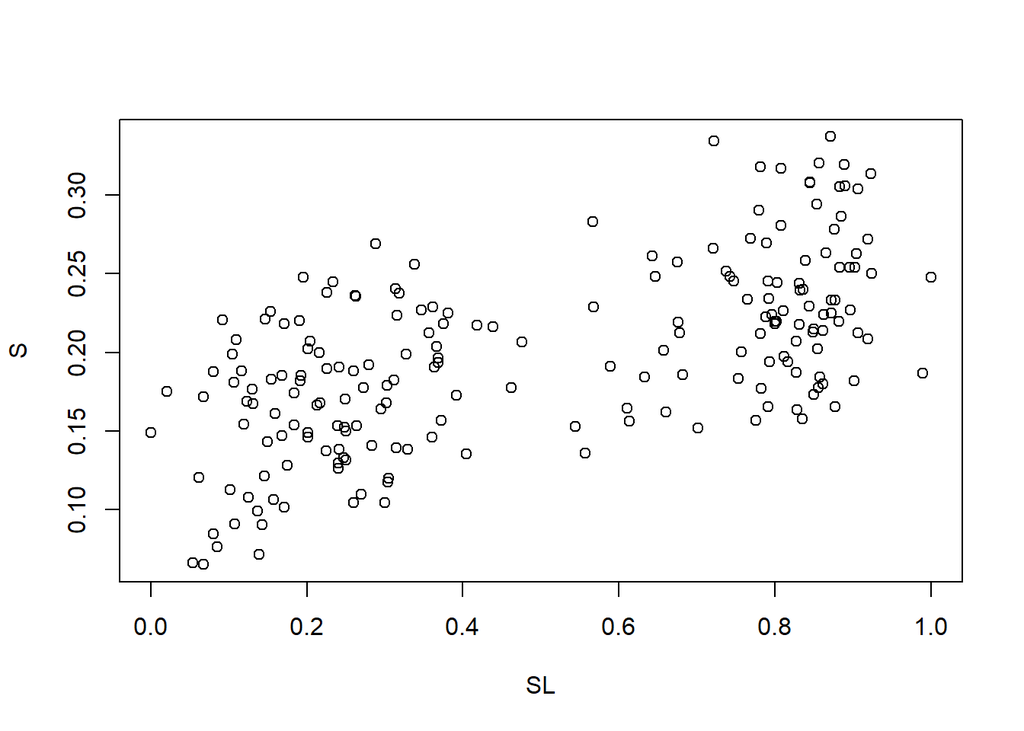

```r
plot(SL, S)
```

```r
# Initialize dK with random numbers
dK<-rbeta(length(T), 1.4,1)*400
# K is affected by SL, Y, S, dK
K<-NULL
for(i in 1:length(T))K[i] <- rnorm(1, SL[i] + 0.1* Y[i] + S[i]- dK[i]/250, 0.2)/9 + 0.4

# Check the data
range(K)# try to make less than 0.5
```

```
## [1] 0.0538841 0.5148786
```

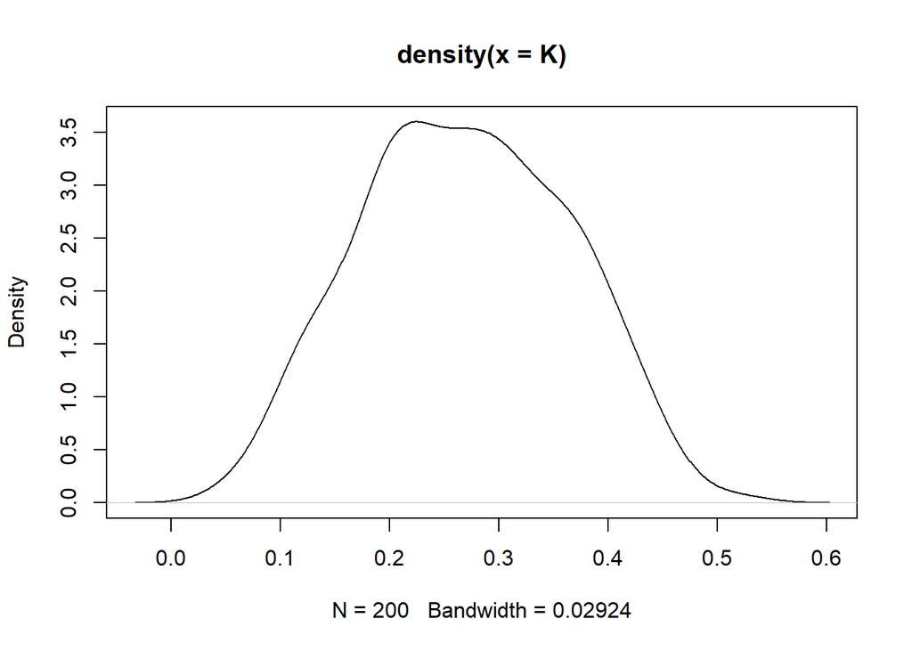

```r
plot(density(K))
```

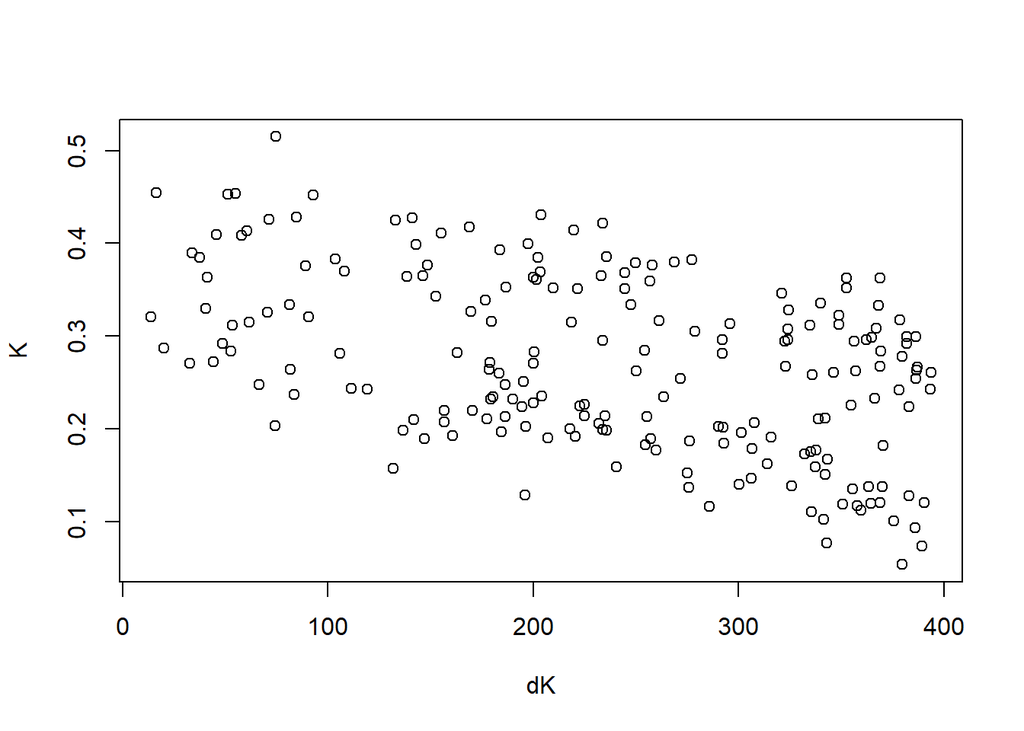

```r
plot(dK, K)
```

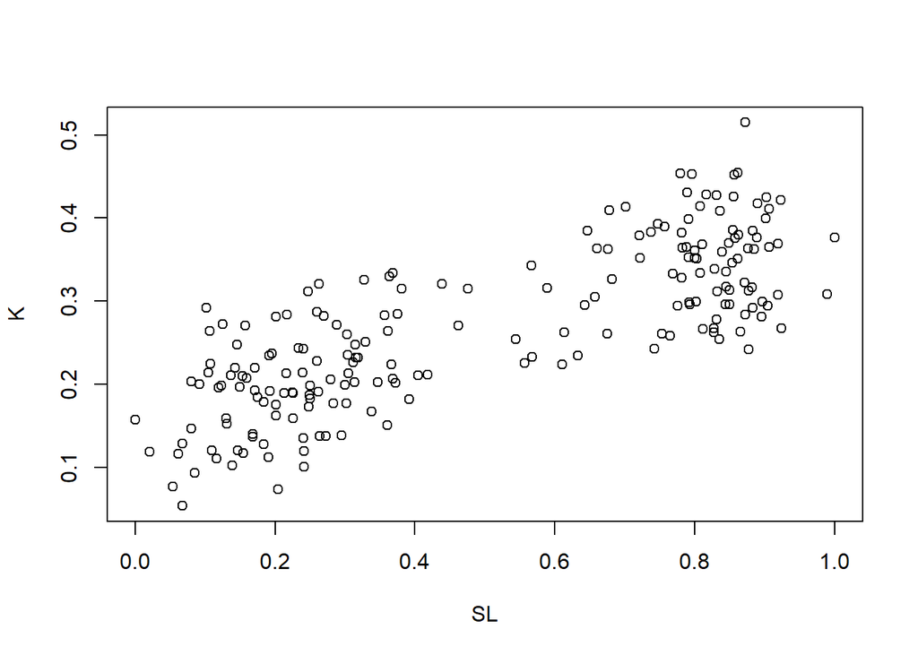

```r
plot(SL, K)
```

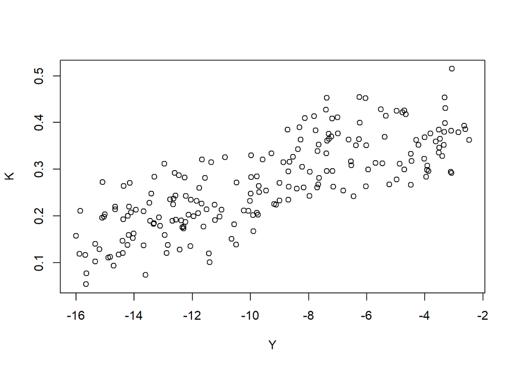

```r
plot(Y, K)
```

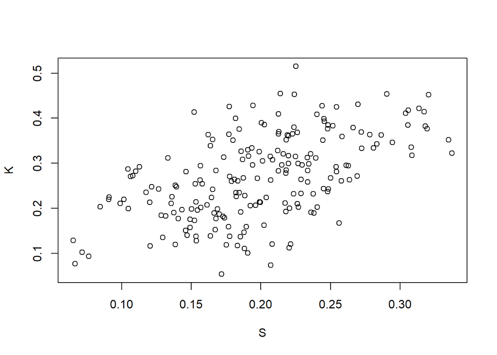

```r
plot(S, K)
```

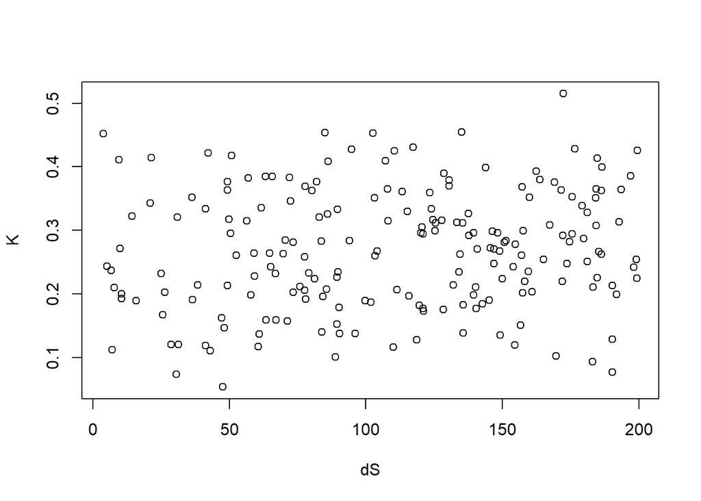

```r
plot(dS, K)
```

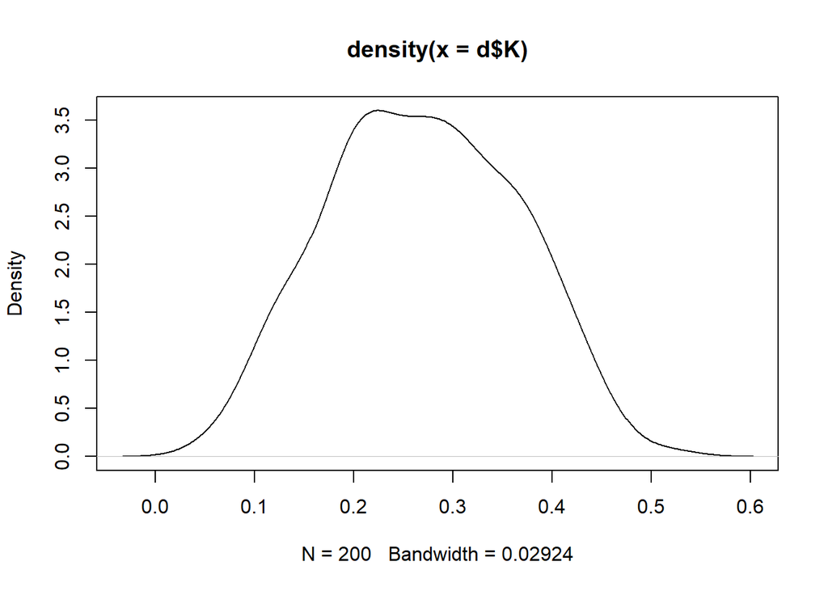

```r
# Standardize data without SL, S, K (those are ratio)
d<-list(T=T, dS=standardize(dS), S=S, K=K, dK=standardize(dK))

# check the data
plot(density(d$K))
```

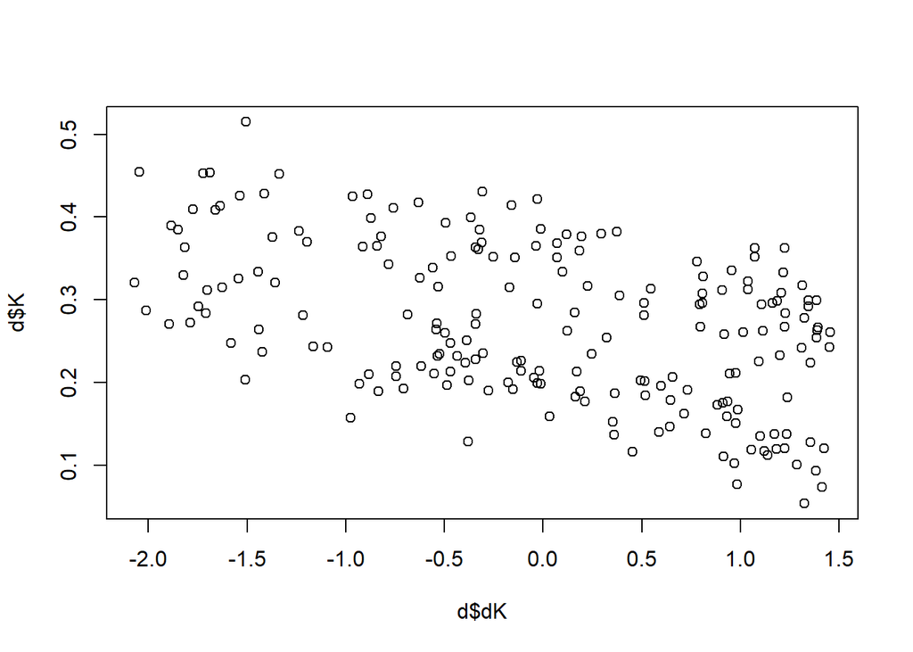

```r
plot(d$dK, d$K)
```

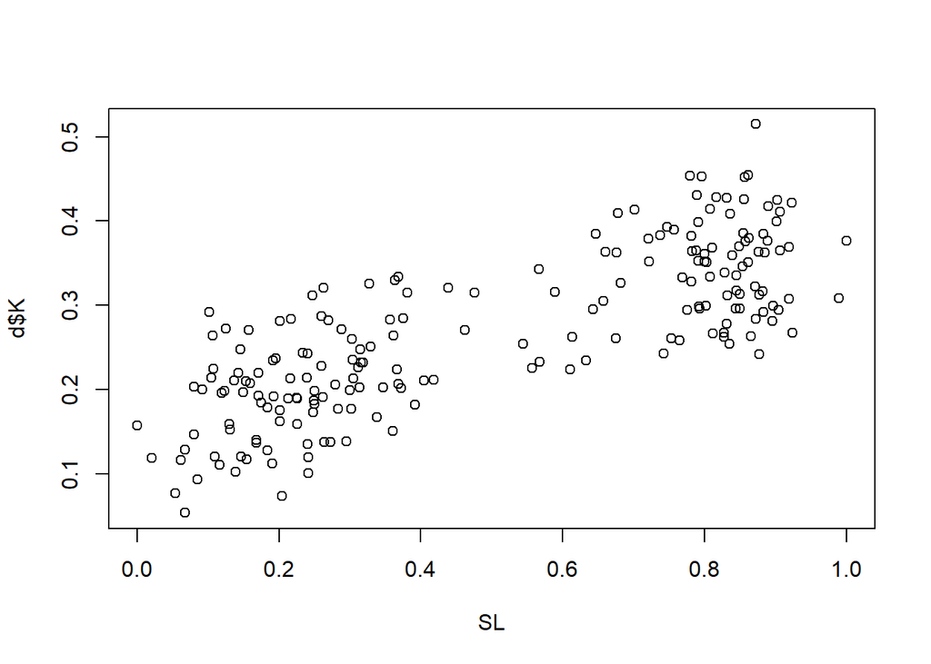

```r
plot(SL, d$K)
```

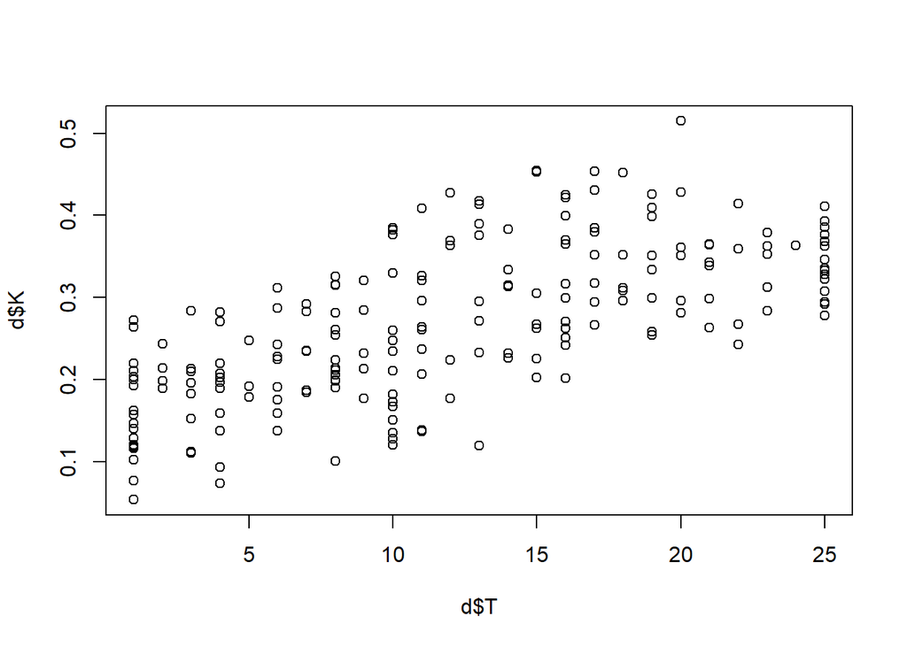

```r
plot(d$T, d$K)
```

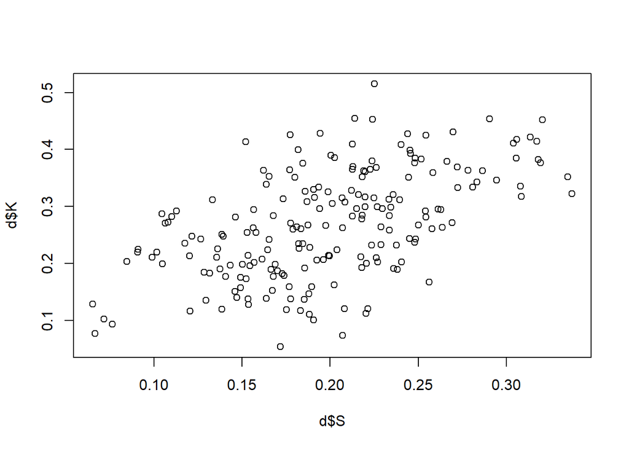

```r
plot(d$S, d$K)
```

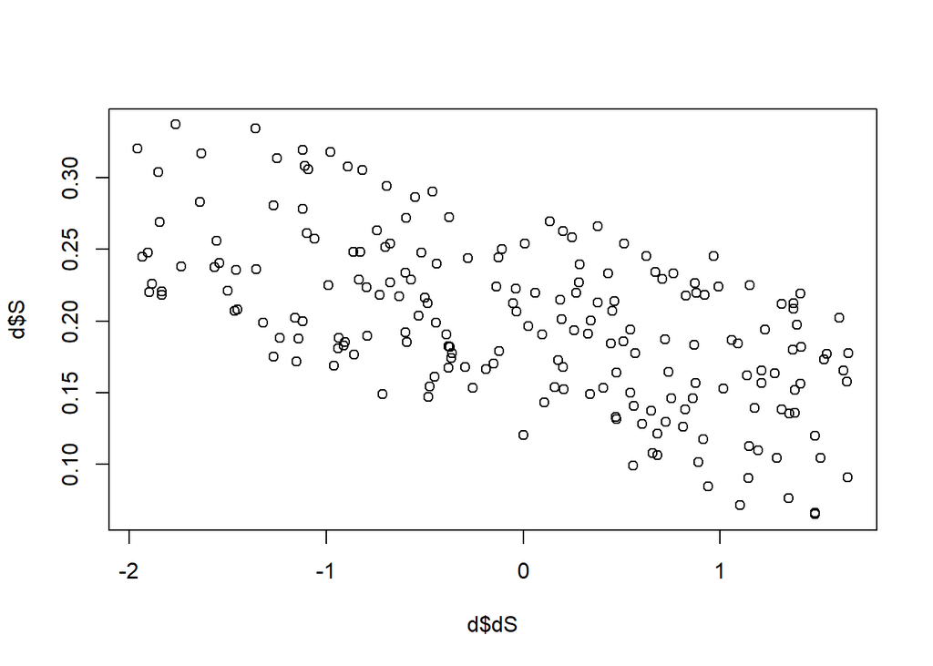

```r
plot(d$dS, d$S)
```

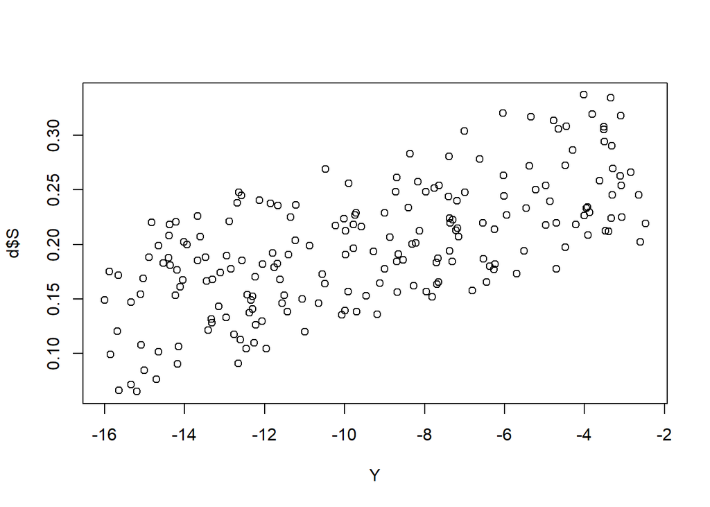

```r
plot(Y, d$S)
```

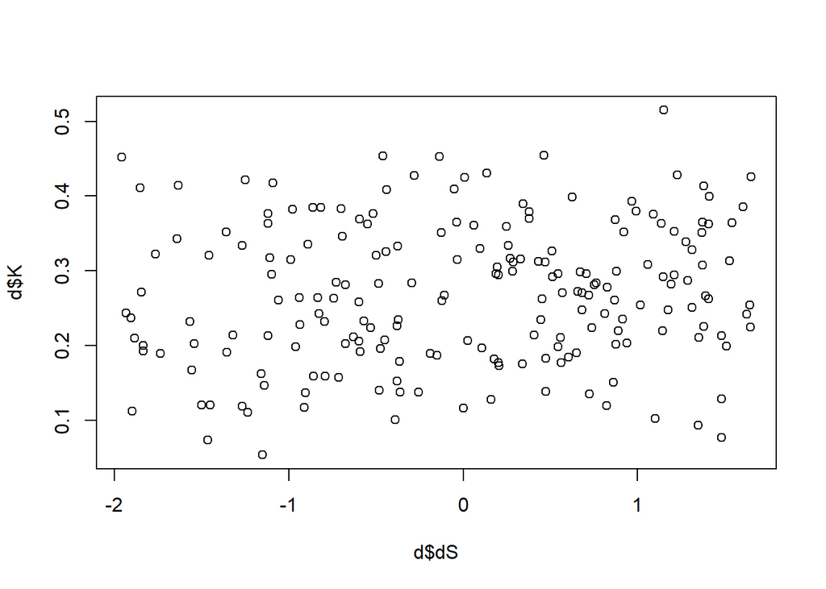

```r
plot(d$dS, d$K) # no correlation
```

## Prior Prediction

- Also see overview.pdf to know statistical model and prior
- There are a few messages to warning my priors.
- This would be due to the prior of Y, which is very weakly initialized. Since it only shows up during first iteration of warmup, we can safely ignore it.
- If you really fix it, you can use normal distribution with large sigma and constraints between -16 and -2.4

```r
# Model 1
m1<- ulam(
    alist (
    # Main model K
        K ~ normal(mu_K, U),
        logit(mu_K) <- aK[T] + bK_S[T] * S + bK_SL[T] * SL[i] + bK_Y[T] * Y[i] + bK_dK * dK,

        # We do not know anything about this but think similar for all group.
        # So use partial pooling to regularize the estimate.
        # mean should start at 0 and has small variation.

        # In this case (m1), we do not include correlation.
        # This is because multilevel models of S and SL includes the information of Y
        # But we have to regularize.
        vector[25]: aK <- aK_bar + sigma_aK * z_aK[T],
        vector [25]: bK_S <- bK_S_bar + sigma_bK_S * z_bK_S[T],
        vector [25]: bK_SL <- bK_SL_bar + sigma_bK_SL * z_bK_SL[T],
        vector [25]: bK_Y <- bK_Y_bar + sigma_bK_Y * z_bK_Y[T],
        c(aK_bar, bK_S_bar,  bK_SL_bar, bK_Y_bar) ~ normal(0,0.3),
        c(sigma_aK, sigma_bK_S, sigma_bK_SL, sigma_bK_Y) ~ exponential(6), # want low variation among groups
        z_aK[T] ~ normal(0,0.01),
        z_bK_S[T] ~ normal(0,0.01),
        z_bK_SL[T] ~ normal(0,0.01),
        z_bK_Y[T] ~ normal(0,0.01),

        # don't need regularization as dK is not affected by T
        # We are hoping/believing b_dK is negative, but this is not prior.
        bK_dK ~ normal(0, 0.5),
        U ~ exponential(1),

    # Model S
        S ~ normal(mu_S, sigma_S),
        logit(mu_S) <- aS[T] + bS_dS * dS + bS_Y[T] * Y[i],

        # I am hoping/believing b_dS is negative and b_Y_S is positive
        # partial pooling for the same reason for a2 and b_Y_S
        vector[25]: aS<-aS_bar + sigma_aS * z_aS[T],
        vector[25]: bS_Y<-bS_Y_bar + sigmabS_Y * zbS_Y[T],
        c(aS_bar, bS_Y_bar) ~ normal(0,0.1),
        c(sigma_aS, sigmabS_Y) ~ exponential(6),
        z_aS[T] ~ normal(0,0.05),
        zbS_Y[T] ~ normal(0,0.05),

        # don't need regularization
        bS_dS ~ normal(0,0.1),
        sigma_S ~ exponential(1),

        # Model SL by Y
        # The log function and prior was refered to the previous research of Sea Level Change over time.
        # This function is abstruct so I will have to actually stan code to provide accurate estimates
        # ulam code in r does not allow us to hartd code the conditional function.
        # vector[200]: SL ~ normal(muSL + aSL2, sigmaSL),
        vector[200]: SL ~ normal(mu_SL, sigma_SL),
        vector[200]: logit(mu_SL) <- aSL + Y[i] * bSL,
        aSL ~ normal(8, 0.01), # very low variation since this part is hard coded.
        bSL ~ normal(0.8, 0.01), # very low variation since this part is hard coded.

        sigma_SL ~ exponential(1),

         # Model T, This should be hard coded based on the previous research
        T ~ poisson((Y + 16)/ ( -2.4 + 16) * 25),

        # Model T by Y
        vector[200]:Y ~ uniform( -16 , -2.4 )

    ), dat = d, constraints = list(
        SL    = "lower=0,upper=1" # SL is between 0 and 1
        #, T    = "lower=1,upper=25"  #this is unnecessary since T is provided in the dat
    ),chains=4, cores=4, log_lik=TRUE
)
```

[output not shown]

[output not shown]

[output not shown]

[output not shown]

```
## Running MCMC with 4 parallel chains, with 1 thread(s) per chain...
##
## Chain 1 Iteration:   1 / 1000 [  0%]  (Warmup)
```

```
## Chain 1 Informational Message: The current Metropolis proposal is about to be rejected because of the following issue:
```

[output not shown]

```
## Chain 1 If this warning occurs sporadically, such as for highly constrained variable types like covariance matrices, then the sampler is fine,
```

```
## Chain 1 but if this warning occurs often then your model may be either severely ill-conditioned or misspecified.
```

```
## Chain 1
```

```
## Chain 2 Iteration:   1 / 1000 [  0%]  (Warmup)
```

```
## Chain 2 Informational Message: The current Metropolis proposal is about to be rejected because of the following issue:
```

[output not shown]

```
## Chain 2 If this warning occurs sporadically, such as for highly constrained variable types like covariance matrices, then the sampler is fine,
```

```
## Chain 2 but if this warning occurs often then your model may be either severely ill-conditioned or misspecified.
```

```
## Chain 2
```

```
## Chain 3 Iteration:   1 / 1000 [  0%]  (Warmup)
```

```
## Chain 3 Informational Message: The current Metropolis proposal is about to be rejected because of the following issue:
```

[output not shown]

```
## Chain 3 If this warning occurs sporadically, such as for highly constrained variable types like covariance matrices, then the sampler is fine,
```

```
## Chain 3 but if this warning occurs often then your model may be either severely ill-conditioned or misspecified.
```

```
## Chain 3
```

```
## Chain 4 Iteration:   1 / 1000 [  0%]  (Warmup)
```

```
## Chain 4 Informational Message: The current Metropolis proposal is about to be rejected because of the following issue:
```

[output not shown]

```
## Chain 4 If this warning occurs sporadically, such as for highly constrained variable types like covariance matrices, then the sampler is fine,
```

```
## Chain 4 but if this warning occurs often then your model may be either severely ill-conditioned or misspecified.
```

```
## Chain 4
```

[output not shown]

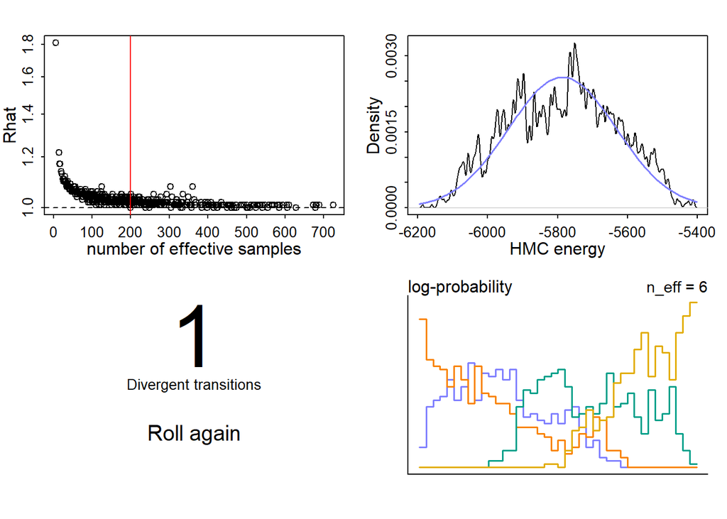

```r
dashboard(m1)
```

```r
precis(m1, depth=1)
```

```
## 550 vector or matrix parameters hidden. Use depth=2 to show them.
```

```
##                     mean          sd          5.5%        94.5%     rhat
## bK_Y_bar     0.064941192 0.010964198  0.0471817405  0.081590939 1.097401
## bK_SL_bar    0.395549375 0.102263888  0.2340750175  0.556759137 1.080138
## bK_S_bar     0.687024729 0.206869404  0.3527893822  1.008661471 1.024348
## aK_bar      -0.781088613 0.165845535 -1.0615495245 -0.529990028 1.109615
## sigma_bK_Y   0.134307501 0.117993047  0.0041089318  0.362682665 1.020469
## sigma_bK_SL  0.169342729 0.176393464  0.0106743310  0.497568396 1.008751
## sigma_bK_S   0.168646234 0.171426411  0.0075771417  0.500031787 1.005646
## sigma_aK     0.170852114 0.161032712  0.0125235651  0.477528464 1.004597
## bK_dK       -0.269233345 0.011032715 -0.2870560047 -0.251855640 1.015139
## U            0.024814982 0.001562519  0.0224082714  0.027370647 1.014310
## bS_Y_bar     0.079779071 0.002944124  0.0751892461  0.084425184 1.038939
## aS_bar      -0.673183717 0.030895928 -0.7186681796 -0.620907224 1.069240
## sigmabS_Y    0.031042426 0.021203289  0.0028803207  0.068166121 1.166428
## sigma_aS     0.131876803 0.112132375  0.0116784231  0.343391285 1.036080
## bS_dS       -0.286217234 0.009431694 -0.3014073273 -0.270609193 1.075880
## sigma_S      0.010006577 0.001211976  0.0080927261  0.011979919 1.217301
## aSL          7.999388652 0.009745463  7.9832398535  8.015577505 1.014669
## bSL          0.802472221 0.009468759  0.7883752610  0.818599247 1.105000
## sigma_SL     0.001671796 0.001236629  0.0004141341  0.004152383 1.814214
##              ess_bulk
## bK_Y_bar     27.46395
## bK_SL_bar    34.15024
## bK_S_bar    206.07647
## aK_bar       24.85898
## sigma_bK_Y  170.00256
## sigma_bK_SL 366.31054
## sigma_bK_S  379.94715
## sigma_aK    450.44016
## bK_dK       279.95988
## U           185.33597
## bS_Y_bar     60.52210
## aS_bar       43.68440
## sigmabS_Y    16.90016
## sigma_aS    202.38737
## bS_dS        41.53295
## sigma_S      13.86324
## aSL         310.87164
## bSL          28.11272
## sigma_SL      5.98270
```

# Posterior Check

```r
post <- extract.samples(m1)
```

## Hidden parameters

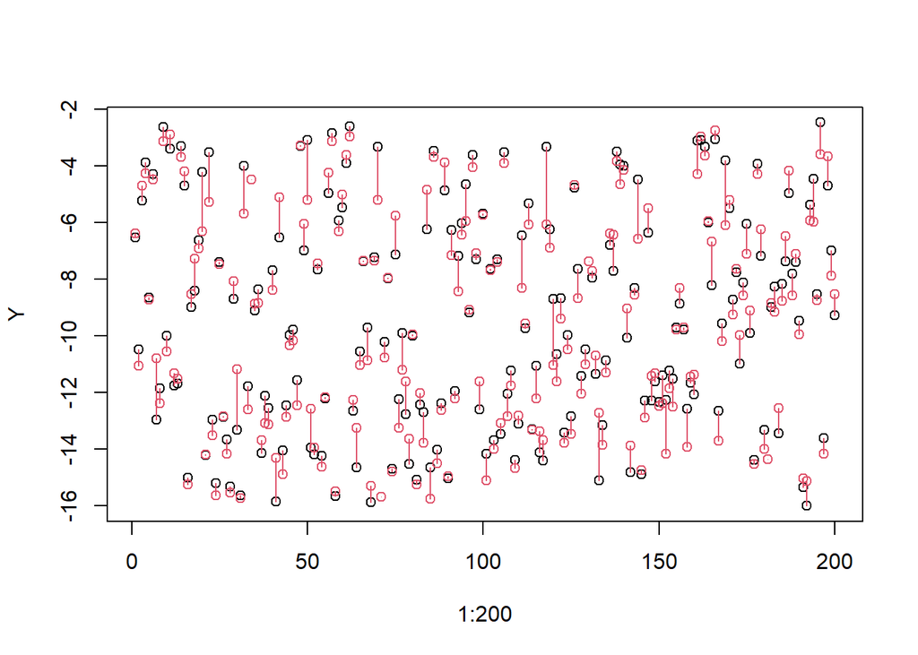

```r
# Posterior Y changes
plot(1:200, Y)
points(1:200, post$Y[1,], col = 2)
for(i in 1 : 200) lines(c(i, i), c(post$Y[1,i], Y[i]), col = 2)
```

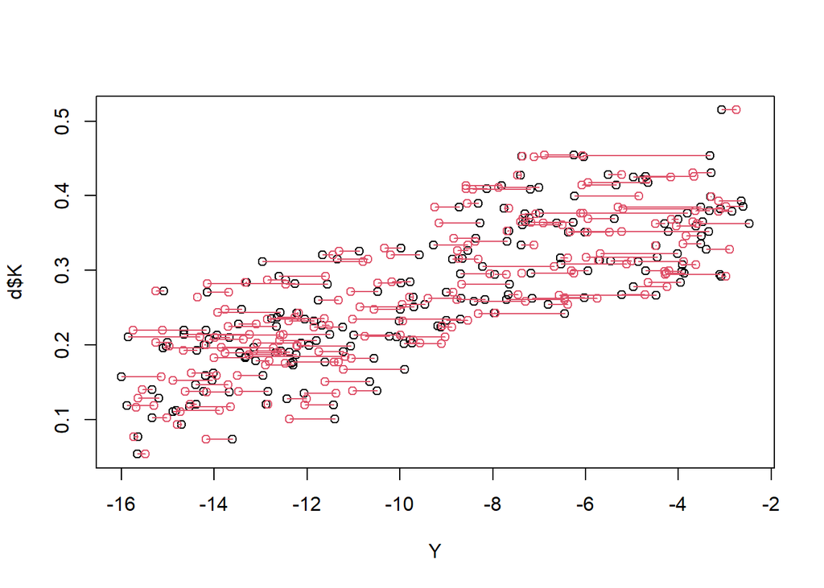

```r
plot(Y, d$K)
points(post$Y[1,], d$K, col = 2)
for(i in 1 : 200) lines(c(post$Y[1,i], Y[i]), c(d$K[i], d$K[i]), col = 2)
```

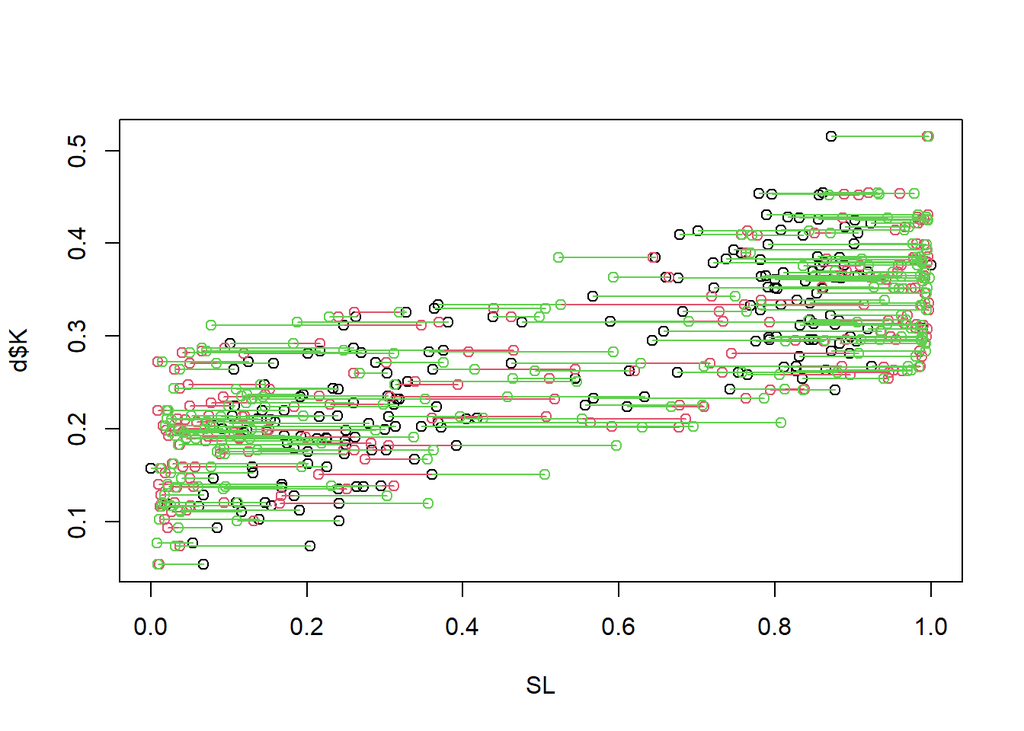

```r
plot(SL, d$K)
points(post$SL[1,], d$K, col = 2)
for(i in 1 : 200) lines(c(post$SL[1,i], SL[i]), c(d$K[i], d$K[i]), col = 2)
points(post$SL[2,], d$K, col = 3)
for(i in 1 : 200) lines(c(post$SL[2,i], SL[i]), c(d$K[i], d$K[i]), col = 3)
```

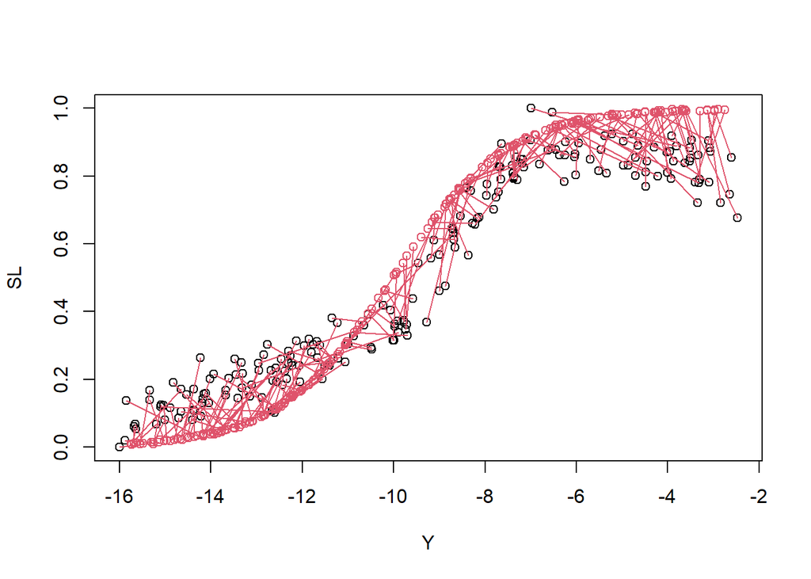

```r
plot(Y, SL)
points(post$Y[1,], post$SL[1,], col=2)
for(i in 1 : 200) lines(c(Y[i], post$Y[1,i]), c(SL[i], post$SL[1,i]), col = 2)
```

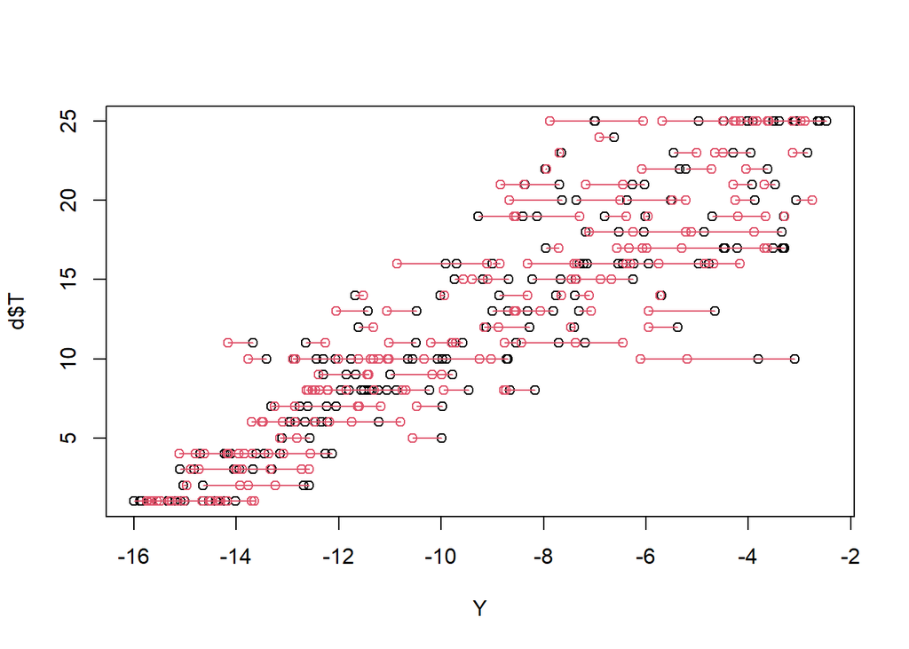

```r
plot(Y, d$T)
points(post$Y[1,], d$T ,col = 2)
for (i in 1:200) lines(c(Y[i], post$Y[1,i]), c(d$T[i],d$T[i]), col = 2)
```